# Assignment for Reproducible Research

Submitted for the compeletion of the course, the assigment is about processing the personal movement activity data caputured using monitoring devices such as a Fitbit, Nike Fuelband, or Jawbone Up. It requires to answer the set of questions as below.

## Loading and preprocessing the data

Reading the csv data file into the data frame and modifying the date format. Then filtering the data to include on the records which are complete.

```r
activity<-read.csv("C:/Users/sachin/Documents/R/repdata-data-activity/activity.csv")
str(activity)
```

```
## 'data.frame':    17568 obs. of  3 variables:
##  $ steps   : int  NA NA NA NA NA NA NA NA NA NA ...
##  $ date    : Factor w/ 61 levels "2012-10-01","2012-10-02",..: 1 1 1 1 1 1 1 1 1 1 ...
##  $ interval: int  0 5 10 15 20 25 30 35 40 45 ...
```

```r
activity$date <- as.Date(activity$date, "%Y-%m-%d")
activity_complete <- activity[complete.cases(activity),]
```

## What is mean total number of steps taken per day?

This is simply done by using the completed set of data and then aggregating on the required date.

```r
## Aggregaing the data based on the date filed and calculating the sum, mean and median for each day
TotalSteps <- aggregate(steps ~ date, data = activity_complete, sum, na.rm = TRUE)
head(TotalSteps)
```

```
##         date steps
## 1 2012-10-02   126
## 2 2012-10-03 11352
## 3 2012-10-04 12116
## 4 2012-10-05 13294
## 5 2012-10-06 15420
## 6 2012-10-07 11015
```

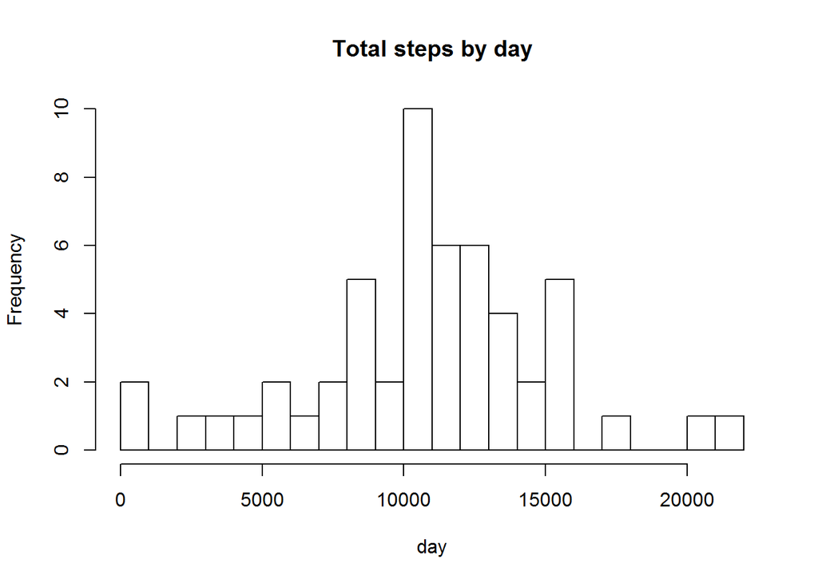

```r
##Plotting the histogram
hist(TotalSteps$steps, main = "Total steps by day", xlab = "day", breaks=30)
```

```r
MeanSteps <- aggregate(steps ~ date, data= activity_complete, mean, na.rm = TRUE)
avg1<-mean(TotalSteps$steps)
med1<-median(TotalSteps$steps)
avg1
```

```
## [1] 10766.19
```

```r
med1
```

```
## [1] 10765
```

As we see above the mean and the median values.

## What is the average daily activity pattern?

To find the daily activity pattern it need to get find mean number of stesp on each interval of the day.

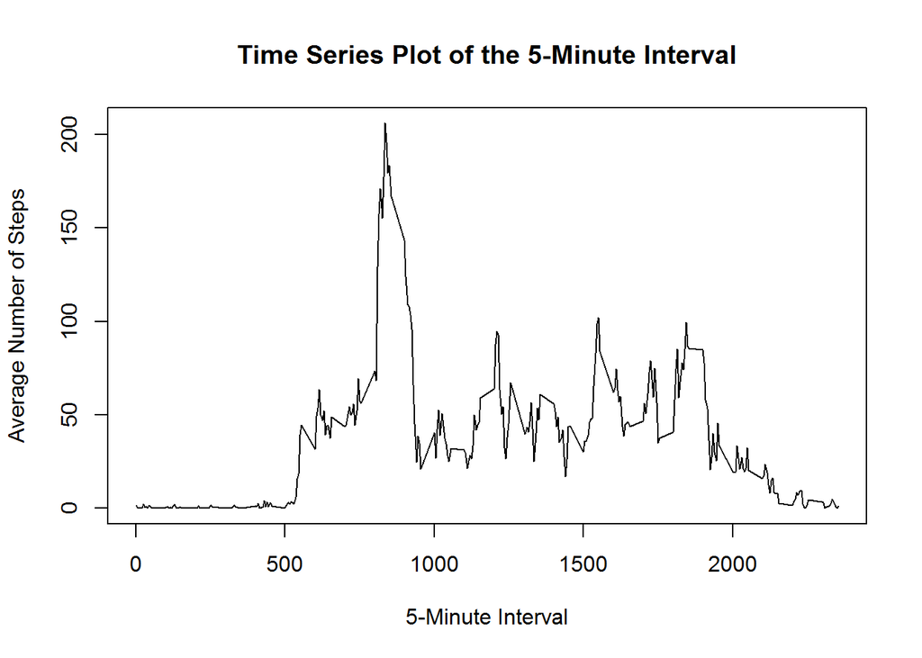

```r
## Aggregaing the data based on the interval field and calculating the  mean for each interval
MeanStepsInterval <- aggregate(steps ~ interval, data= activity_complete, mean,na.rm = TRUE)
names(MeanStepsInterval)[2] <- "mean_steps"
## Plotting the mean data for each interval
plot(x = MeanStepsInterval$interval,y = MeanStepsInterval$mean_steps,type = "l",
    main = "Time Series Plot of the 5-Minute Interval",
    xlab = "5-Minute Interval",
    ylab = "Average Number of Steps")
```

```r
## Finding the inteval which has the maximum value of the mean steps
MeanStepsInterval[MeanStepsInterval$mean_steps==max(MeanStepsInterval$mean_steps),]
```

```
##     interval mean_steps
## 104      835   206.1698
```

## Imputing missing values

Finding the number of records which has missing Steps data and contain NA and replacing them with the mean of that particular day.

```r
nrow(activity[is.na(activity$steps),])
```

```
## [1] 2304
```

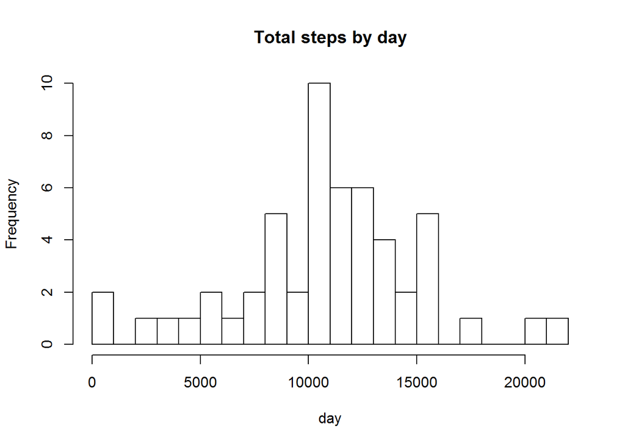

```r
## merging the missing data with the means number of steps on that day
newactivity <- merge(activity, MeanSteps, by = 'date', all.y = F)
names(newactivity)[2] <- "steps"
names(newactivity)[4] <- "day_mean_steps"

## Replacing the NA values with the Mean of the day value
newactivity$steps[is.na(newactivity$steps)] <- as.integer(
        round(newactivity$day_mean_steps[is.na(newactivity$steps)]))

TotalSteps2 <- aggregate(steps ~ date, data = newactivity, sum, na.rm = TRUE)
hist(TotalSteps2$steps, main = "Total steps by day", xlab = "day", breaks=30)
```

```r
MeanSteps <- aggregate(steps ~ date, data = newactivity, mean, na.rm = TRUE)
MedianSteps <- aggregate(steps ~ date, data = newactivity, median, na.rm = TRUE)

## New Mean & Median after populating missing data
avg2<-mean(TotalSteps2$steps)
med2<-median(TotalSteps2$steps)
avg2
```

```
## [1] 10766.19
```

```r
med2
```

```
## [1] 10765
```

After inputting missing values, we see the the new mean and median do not differ much from the one that we got by excluding the missing values.

## Are there differences in activity patterns between weekdays and weekends?

This requires to first categories the data record into a weekday and weekend record by adding a new field

```r
## se up a new column  day type and set it to value weekday. Then determine the rows which are saturday or sunday and update their dayype column to weekend.
newactivity$daytype <- "weekday"
weekend <- weekdays(as.Date(newactivity$date)) %in% c("Saturday", "Sunday")
newactivity$daytype[weekend == TRUE] <- "weekend"

## convert new character column to factor
newactivity$daytype <- as.factor(newactivity$daytype)
```

The new data set with the additional field is then used to find the mean for each categoy of the day.

```r
newMeanStepsInterval <- aggregate(steps ~ interval + daytype, data =newactivity, mean)
head(newMeanStepsInterval)
```

```
##   interval daytype     steps
## 1        0 weekday 2.3333333
## 2        5 weekday 0.4615385
## 3       10 weekday 0.1794872
## 4       15 weekday 0.2051282
## 5       20 weekday 0.1025641
## 6       25 weekday 1.5128205
```

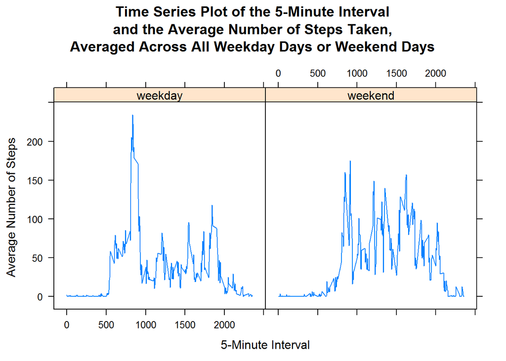

```r
names(newMeanStepsInterval)[3] <- "mean_steps"

##Plotting the graphs for mean value of interval for both weekday& weekend
library(lattice)
xyplot( mean_steps ~ interval|daytype ,data= newMeanStepsInterval,
        type = "l",
      main = "Time Series Plot of the 5-Minute Interval\nand the Average Number of Steps Taken,\nAveraged Across All Weekday Days or Weekend Days",
        xlab = "5-Minute Interval",
        ylab = "Average Number of Steps ")
```

As we see in teh graphs that the values/pattern is different between week day and weekends

This concludes the assignment by answering all the questions.